# What I watch: A Visual Story of My YouTube Habits

## What am I watching?

For the past few weeks I’ve been logging every YouTube video I watch using a Google Form. After 42 videos I can start to see some real patterns in what I watch, how long those videos are, and when in the day I tend to watch them.

[figure not shown]

Bar chart showing Gaming as the most watched category at 8 videos, followed by Tech at 7 and Other at 7, then Comedy, Music, Education, Vlogs, and Sports at the bottom

Gaming is the most common category in my log, closely followed by Tech and Other. This matches what I’d expect as these are the topics YouTube most often recommends to me.

## How long are these videos?

Counting videos is one thing, but it doesn’t tell the full story. Some categories show up often as short clips, while others tend to be long-form content.

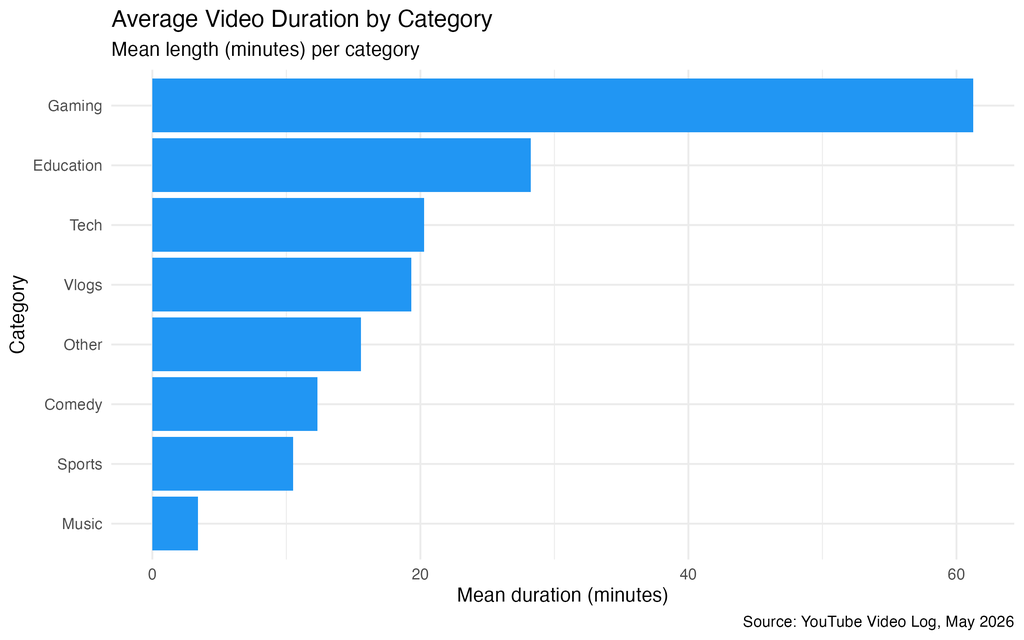

Gaming is the biggest in both ways. Not just the number of videos but also how long they are. The average gaming video is over 60 minutes long which is mostly because of the long walkthrough videos I watch.

## When do I watch?

Because every form submission is automatically timestamped, I can see when in the day I’m most often hitting play.

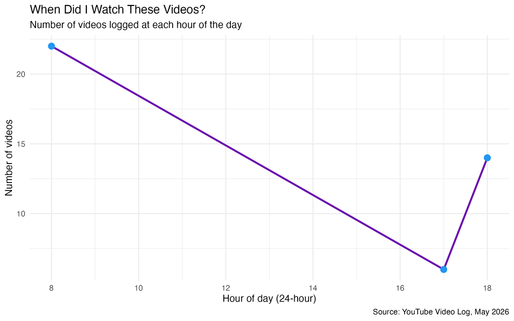

Line and point chart showing number of videos logged at each hour of the day, with a clear peak at 8 AM and another at 6 PM, and a dip in between

The data clusters into morning and evening, before classes start at around 8 AM, and again around dinner time at 6 PM. The middle of the day is much quieter because I’m in lectures/studying or doing assignments.

## What did I learn?

Looking across all 42 videos, the patterns are pretty clear. I watch a lot of long Gaming and Tech videos and I tend to watch them either before class or after dinner. Logging this for STATS 220 was actually interesting because I knew I watched a lot of YouTube but I didn’t really realise how much of it was Gaming until I saw the chart.